# F9_07_COMP_KONTR_ADDR_L2

Independent contractor street address line 2 · Code report

## Overview

**Description**

Highest compensated independent contractor (top 5 above 100K) foreign address line 2

**Table**

`F9-P07-T02-CONTRACTORS` (many)

**Location code**

`F990-PC-PART-07-SECTION-B-LINE-01-COL-A`, `F990-EZ-PART-06-LINE-51-COL-A`

**Family**

`F990-PC-PART-07-SECTION-B-LINE-01-COL-A` · siblings: F9_07_COMP_KONTR_ADDR_CITY, F9_07_COMP_KONTR_ADDR_CNTR, F9_07_COMP_KONTR_ADDR_L1, F9_07_COMP_KONTR_ADDR_STATE, F9_07_COMP_KONTR_ADDR_ZIP, F9_07_COMP_KONTR_NAME_ORG_L1

**Data type**

text (xsd: StreetAddressType, , CountryType)

**Scope**

PZ

**Status**

unreviewed

14

xpaths mapped (9 observed)

15,340

filings with a value

2009–2024

tax years observed

10

open flags (1 errors)

## Flags

| Severity | Flag | Xpath | Detail |
| --- | --- | --- | --- |
| ⚠ error | `COLLISION` | IRS990/ContractorCompensationGrp/ContractorAddress/ForeignAddress/AddressLine2Txt | 170 filings contain 2+ of its xpaths; most common set: /Return/ReturnData/IRS990/ContractorCompensationGrp/ContractorAddress/ForeignAddress/AddressLine2Txt ; /Return/ReturnData/IRS990/ContractorCompen… |
| ▲ warn | `GAP` |  | no 990EZ filings in 2010,2011,2013,2014,2016,2017, but filings before and after |
| ⓘ info | `MANY_NOT_REPEATING` | IRS990EZ/CompensationOfHghstPdCntrctGrp/USAddress/AddressLine2Txt | many-to-one table, but 86% of values sit in no repeating element |
| ⓘ info | `MANY_NOT_REPEATING` | IRS990EZ/CompensationOfHghstPdCntrctGrp/ForeignAddress/AddressLine2Txt | many-to-one table, but 92% of values sit in no repeating element |
| ⓘ info | `MANY_NOT_REPEATING` | IRS990EZ/CompOfHghstPaidCntrctProfSer/AddressUS/AddressLine2 | many-to-one table, but 100% of values sit in no repeating element |
| ⓘ info | `UNOBSERVED` | IRS990/Form990PartVIISectionB/ContractorCompensation/AddressOfContractor/AddressForeign/AddressLine2 | never observed in TY2009-2024 filings |
| ⓘ info | `UNOBSERVED` | IRS990/Form990PartVIISectionB/ContractorCompensation/AddressOfContractor/AddressUS/AddressLine2 | never observed in TY2009-2024 filings |
| ⓘ info | `UNOBSERVED` | IRS990EZ/CompOfHghstPaidCntrctProfSer/AddressForeign/AddressLine2 | never observed in TY2009-2024 filings |
| ⓘ info | `UNOBSERVED` | IRS990EZ/CompensationOfHghstPdCntrctGrp/ForeignAddress/AddressLine2 | never observed in TY2009-2024 filings |
| ⓘ info | `UNOBSERVED` | IRS990EZ/CompensationOfHghstPdCntrctGrp/USAddress/AddressLine2 | never observed in TY2009-2024 filings |

## Xpaths

All mapped xpaths (under /Return/ReturnData or /Return/ReturnHeader), oldest first. Charts label each series by its xpath.

| Xpath | Form | Chart label | First year | Last year | Versions | Filings | Repeats in |
| --- | --- | --- | --- | --- | --- | --- | --- |
| IRS990/ContractorCompensation/AddressOfContractor/AddressUS/AddressLine2 | 990 | …orCompensation/AddressOfContractor/AddressUS/AddressLine2 | 2009 | 2012 | 16 | 1,703 | 32.0% |
| IRS990/ContractorCompensation/AddressOfContractor/AddressForeign/AddressLine2 | 990 | …pensation/AddressOfContractor/AddressForeign/AddressLine2 | 2009 | 2012 | 6 | 61 | 24.6% |
| IRS990EZ/CompOfHghstPaidCntrctProfSer/AddressUS/AddressLine2 | 990-EZ | same | 2009 | 2012 | 2 | 2 | 0.0% |
| IRS990/ContractorCompensationGrp/ContractorAddress/USAddress/AddressLine2 | 990 | …rCompensationGrp/ContractorAddress/USAddress/AddressLine2 | 2013 | 2013 | 3 | 549 | 33.3% |
| IRS990/ContractorCompensationGrp/ContractorAddress/ForeignAddress/AddressLine2 | 990 | …ensationGrp/ContractorAddress/ForeignAddress/AddressLine2 | 2013 | 2013 | 2 | 22 | 27.3% |
| IRS990/ContractorCompensationGrp/ContractorAddress/USAddress/AddressLine2Txt | 990 | …mpensationGrp/ContractorAddress/USAddress/AddressLine2Txt | 2014 | 2024 | 28 | 12,332 | 32.9% |
| IRS990/ContractorCompensationGrp/ContractorAddress/ForeignAddress/AddressLine2Txt | 990 | …ationGrp/ContractorAddress/ForeignAddress/AddressLine2Txt | 2014 | 2024 | 24 | 603 | 34.2% |
| IRS990/Form990PartVIISectionB/ContractorCompensation/AddressOfContractor/AddressForeign/AddressLine2 | 990 | Other |  |  |  | 0 |  |
| IRS990/Form990PartVIISectionB/ContractorCompensation/AddressOfContractor/AddressUS/AddressLine2 | 990 | Other |  |  |  | 0 |  |
| IRS990EZ/CompOfHghstPaidCntrctProfSer/AddressForeign/AddressLine2 | 990-EZ | Other |  |  |  | 0 |  |
| IRS990EZ/CompensationOfHghstPdCntrctGrp/ForeignAddress/AddressLine2 | 990-EZ | Other |  |  |  | 0 |  |
| IRS990EZ/CompensationOfHghstPdCntrctGrp/ForeignAddress/AddressLine2Txt | 990-EZ | Other | 2015 | 2024 | 8 | 12 | 8.3% |
| IRS990EZ/CompensationOfHghstPdCntrctGrp/USAddress/AddressLine2 | 990-EZ | Other |  |  |  | 0 |  |
| IRS990EZ/CompensationOfHghstPdCntrctGrp/USAddress/AddressLine2Txt | 990-EZ | Other | 2018 | 2024 | 11 | 56 | 7.1% |

## Coverage

[figure not shown]

**Table view**

Table view: filings by tax year and series

| Tax year | …orCompensation/AddressOfContractor/AddressUS/AddressLine2 | …pensation/AddressOfContractor/AddressForeign/AddressLine2 | IRS990EZ/CompOfHghstPaidCntrctProfSer/AddressUS/AddressLine2 | …rCompensationGrp/ContractorAddress/USAddress/AddressLine2 | …ensationGrp/ContractorAddress/ForeignAddress/AddressLine2 | …mpensationGrp/ContractorAddress/USAddress/AddressLine2Txt | …ationGrp/ContractorAddress/ForeignAddress/AddressLine2Txt | Other |
| --- | --- | --- | --- | --- | --- | --- | --- | --- |
| 2009 | 266 | 15 | 1 | 0 | 0 | 0 | 0 | 0 |
| 2010 | 437 | 17 | 0 | 0 | 0 | 0 | 0 | 0 |
| 2011 | 475 | 15 | 0 | 0 | 0 | 0 | 0 | 0 |
| 2012 | 525 | 14 | 1 | 0 | 0 | 0 | 0 | 0 |
| 2013 | 0 | 0 | 0 | 549 | 22 | 0 | 0 | 0 |
| 2014 | 0 | 0 | 0 | 0 | 0 | 720 | 25 | 0 |
| 2015 | 0 | 0 | 0 | 0 | 0 | 820 | 23 | 1 |
| 2016 | 0 | 0 | 0 | 0 | 0 | 907 | 35 | 0 |
| 2017 | 0 | 0 | 0 | 0 | 0 | 949 | 36 | 0 |
| 2018 | 0 | 0 | 0 | 0 | 0 | 989 | 28 | 2 |
| 2019 | 0 | 0 | 0 | 0 | 0 | 999 | 38 | 3 |
| 2020 | 0 | 0 | 0 | 0 | 0 | 1,140 | 66 | 4 |
| 2021 | 0 | 0 | 0 | 0 | 0 | 1,257 | 69 | 13 |
| 2022 | 0 | 0 | 0 | 0 | 0 | 1,421 | 92 | 13 |
| 2023 | 0 | 0 | 0 | 0 | 0 | 1,814 | 99 | 17 |
| 2024 | 0 | 0 | 0 | 0 | 0 | 1,316 | 92 | 15 |

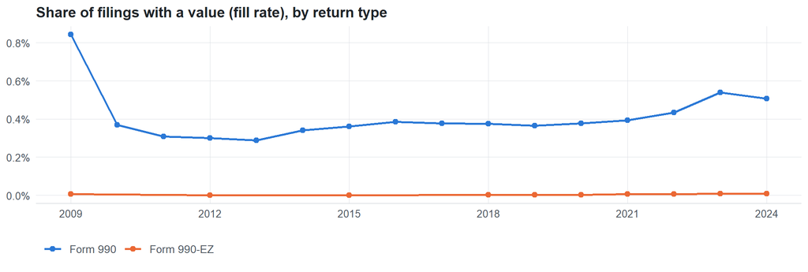

**Table view**

Table view: fill rate

| Tax year | Return type | Filings | All filings | Fill rate |
| --- | --- | --- | --- | --- |
| 2009 | Form 990 | 281 | 33,311 | 0.84% |
| 2009 | Form 990-EZ | 1 | 15,470 | 0.01% |
| 2010 | Form 990 | 454 | 123,025 | 0.37% |
| 2011 | Form 990 | 490 | 159,504 | 0.31% |
| 2012 | Form 990 | 539 | 179,688 | 0.30% |
| 2012 | Form 990-EZ | 1 | 93,750 | 0.00% |
| 2013 | Form 990 | 571 | 198,855 | 0.29% |
| 2014 | Form 990 | 745 | 218,619 | 0.34% |
| 2015 | Form 990 | 843 | 233,519 | 0.36% |
| 2015 | Form 990-EZ | 1 | 124,894 | 0.00% |
| 2016 | Form 990 | 942 | 243,903 | 0.39% |
| 2017 | Form 990 | 985 | 261,612 | 0.38% |
| 2018 | Form 990 | 1,017 | 271,442 | 0.37% |
| 2018 | Form 990-EZ | 2 | 149,384 | 0.00% |
| 2019 | Form 990 | 1,037 | 283,694 | 0.37% |
| 2019 | Form 990-EZ | 3 | 152,622 | 0.00% |
| 2020 | Form 990 | 1,206 | 320,342 | 0.38% |
| 2020 | Form 990-EZ | 4 | 169,864 | 0.00% |
| 2021 | Form 990 | 1,326 | 336,480 | 0.39% |
| 2021 | Form 990-EZ | 13 | 202,724 | 0.01% |
| 2022 | Form 990 | 1,513 | 349,055 | 0.43% |
| 2022 | Form 990-EZ | 13 | 206,130 | 0.01% |
| 2023 | Form 990 | 1,913 | 354,768 | 0.54% |
| 2023 | Form 990-EZ | 17 | 206,379 | 0.01% |
| 2024 | Form 990 | 1,408 | 277,298 | 0.51% |
| 2024 | Form 990-EZ | 15 | 178,867 | 0.01% |

## Repeating groups

Table cardinality in the concordance: **many**. 8 of 9 observed xpaths repeat within a filing.

Repeating element each xpath was observed in (from the raw indexed xpath)

| Xpath | Repeating element | Filings (summed over years) |
| --- | --- | --- |
| IRS990/ContractorCompensation/AddressOfContractor/AddressForeign/AddressLine2 | (none) | 7 |
| IRS990/ContractorCompensation/AddressOfContractor/AddressForeign/AddressLine2 | IRS990/ContractorCompensation | 54 |
| IRS990/ContractorCompensation/AddressOfContractor/AddressUS/AddressLine2 | (none) | 327 |
| IRS990/ContractorCompensation/AddressOfContractor/AddressUS/AddressLine2 | IRS990/ContractorCompensation | 1376 |
| IRS990EZ/CompOfHghstPaidCntrctProfSer/AddressUS/AddressLine2 | (none) | 2 |
| IRS990/ContractorCompensationGrp/ContractorAddress/ForeignAddress/AddressLine2 | (none) | 3 |
| IRS990/ContractorCompensationGrp/ContractorAddress/ForeignAddress/AddressLine2 | IRS990/ContractorCompensationGrp | 19 |
| IRS990/ContractorCompensationGrp/ContractorAddress/USAddress/AddressLine2 | (none) | 147 |
| IRS990/ContractorCompensationGrp/ContractorAddress/USAddress/AddressLine2 | IRS990/ContractorCompensationGrp | 402 |
| IRS990/ContractorCompensationGrp/ContractorAddress/ForeignAddress/AddressLine2Txt | (none) | 72 |
| IRS990/ContractorCompensationGrp/ContractorAddress/ForeignAddress/AddressLine2Txt | IRS990/ContractorCompensationGrp | 531 |
| IRS990/ContractorCompensationGrp/ContractorAddress/USAddress/AddressLine2Txt | (none) | 2343 |
| IRS990/ContractorCompensationGrp/ContractorAddress/USAddress/AddressLine2Txt | IRS990/ContractorCompensationGrp | 9989 |
| IRS990EZ/CompensationOfHghstPdCntrctGrp/ForeignAddress/AddressLine2Txt | (none) | 11 |
| IRS990EZ/CompensationOfHghstPdCntrctGrp/USAddress/AddressLine2Txt | (none) | 48 |
| IRS990EZ/CompensationOfHghstPdCntrctGrp/USAddress/AddressLine2Txt | IRS990EZ/CompensationOfHghstPdCntrctGrp | 8 |
| IRS990EZ/CompensationOfHghstPdCntrctGrp/ForeignAddress/AddressLine2Txt | IRS990EZ/CompensationOfHghstPdCntrctGrp | 1 |

## Values

| Result | Check | Detail |
| --- | --- | --- |
| ▲ warn | Small code list | up to 1409 distinct values per xpath and year |
| ▲ warn | Codes share one format | 58% have the shape AAAAA 999 |
| ✓ pass | Consistent letter case | 0.1% of values are lower case |

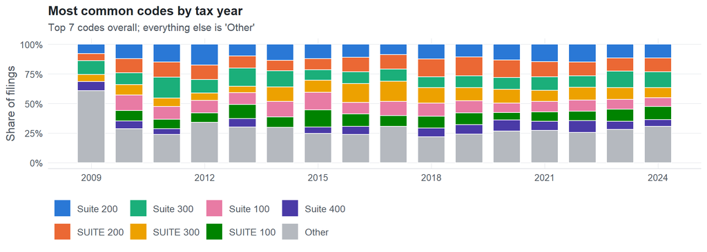

**Table view**

Table view: filings by code and tax year

| tax_year | Suite 200 | SUITE 200 | Suite 300 | SUITE 300 | Suite 100 | SUITE 100 | Suite 400 | Other |
| --- | --- | --- | --- | --- | --- | --- | --- | --- |
| 2009 | 4 | 3 | 6 | 3 | 0 | 0 | 4 | 31 |
| 2010 | 11 | 11 | 9 | 8 | 12 | 8 | 6 | 26 |
| 2011 | 15 | 13 | 18 | 7 | 11 | 8 | 5 | 24 |
| 2012 | 20 | 14 | 13 | 7 | 12 | 9 | 0 | 39 |
| 2013 | 11 | 11 | 17 | 6 | 11 | 13 | 8 | 33 |
| 2014 | 20 | 13 | 20 | 18 | 19 | 13 | 0 | 44 |
| 2015 | 22 | 17 | 16 | 19 | 27 | 26 | 10 | 45 |
| 2016 | 22 | 25 | 20 | 32 | 20 | 21 | 14 | 48 |
| 2017 | 20 | 28 | 23 | 39 | 27 | 21 | 0 | 70 |
| 2018 | 29 | 35 | 21 | 30 | 26 | 23 | 17 | 51 |
| 2019 | 24 | 36 | 22 | 25 | 23 | 22 | 18 | 54 |
| 2020 | 33 | 37 | 25 | 29 | 20 | 16 | 23 | 67 |
| 2021 | 39 | 33 | 30 | 25 | 23 | 21 | 20 | 72 |
| 2022 | 47 | 37 | 31 | 34 | 30 | 25 | 31 | 81 |
| 2023 | 42 | 40 | 50 | 36 | 30 | 37 | 25 | 101 |
| 2024 | 28 | 29 | 32 | 21 | 18 | 27 | 14 | 75 |

Code frequencies (all xpaths, all years)

| Code | Filings | Share |
| --- | --- | --- |
| Suite 200 | 387 | 12.4% |
| SUITE 200 | 382 | 12.3% |
| Suite 300 | 353 | 11.3% |
| SUITE 300 | 339 | 10.9% |
| Suite 100 | 309 | 9.9% |
| SUITE 100 | 290 | 9.3% |
| Suite 400 | 195 | 6.3% |
| SUITE 400 | 122 | 3.9% |
| Suite 500 | 84 | 2.7% |
| Suite 600 | 72 | 2.3% |
| STE 200 | 56 | 1.8% |
| STE 400 | 56 | 1.8% |
| SUITE 600 | 45 | 1.4% |
| STE 100 | 45 | 1.4% |
| SUITE 350 | 36 | 1.2% |
| SUITE 500 | 33 | 1.1% |
| Suite 201 | 22 | 0.7% |
| STE 300 | 22 | 0.7% |
| 2nd Floor | 12 | 0.4% |
| Unit 9 | 10 | 0.3% |
| SUITE A | 7 | 0.2% |
| 5th Floor | 7 | 0.2% |
| SUITE 201 | 7 | 0.2% |
| Suite 800 | 5 | 0.2% |
| 3 Fountain Drive | 5 | 0.2% |
| 104 | 5 | 0.2% |
| 1 Cleve Road | 4 | 0.1% |
| 5 Regency Drive | 4 | 0.1% |
| Andheri Kurla Road | 4 | 0.1% |
| Suite 700 | 4 | 0.1% |

First rows shown.

## Examples

| Tax year | Return | Xpath | Organization | Value | Source |
| --- | --- | --- | --- | --- | --- |
| 2024 | 990 | IRS990/ContractorCompensationGrp/ContractorAddress/ForeignAddress/AddressLine2Txt | Alpha International | Tunbridge Wells | [XML](https://gt990datalake-rawdata.s3.amazonaws.com/EfileData/XmlFiles/202543179349304964_public.xml) |
| 2024 | 990 | IRS990/ContractorCompensationGrp/ContractorAddress/USAddress/AddressLine2Txt | YMCA OF THE FOOTHILLS | 8 | [XML](https://gt990datalake-rawdata.s3.amazonaws.com/EfileData/XmlFiles/202532059349301333_public.xml) |
| 2024 | 990EZ | IRS990EZ/CompensationOfHghstPdCntrctGrp/ForeignAddress/AddressLine2Txt | THYMUS MEETING ASSOCIATION | 4631 202 Street | [XML](https://gt990datalake-rawdata.s3.amazonaws.com/EfileData/XmlFiles/202500479349200120_public.xml) |
| 2024 | 990EZ | IRS990EZ/CompensationOfHghstPdCntrctGrp/USAddress/AddressLine2Txt | OPERATION SPAY NEUTER INC | Suite 103 | [XML](https://gt990datalake-rawdata.s3.amazonaws.com/EfileData/XmlFiles/202540639349200604_public.xml) |
| 2023 | 990 | IRS990/ContractorCompensationGrp/ContractorAddress/ForeignAddress/AddressLine2Txt | SRI RAM SAMSTHAN INC | NANDYALA ROAD | [XML](https://gt990datalake-rawdata.s3.amazonaws.com/EfileData/XmlFiles/202423059349302312_public.xml) |
| 2023 | 990 | IRS990/ContractorCompensationGrp/ContractorAddress/USAddress/AddressLine2Txt | OHIO EDUCATION POLICY INSTITUTE | 2ND FLOOR | [XML](https://gt990datalake-rawdata.s3.amazonaws.com/EfileData/XmlFiles/202442779349301239_public.xml) |
| 2023 | 990EZ | IRS990EZ/CompensationOfHghstPdCntrctGrp/ForeignAddress/AddressLine2Txt | CHINA KINGDOM RESOURCES | 1905 Building 6 | [XML](https://gt990datalake-rawdata.s3.amazonaws.com/EfileData/XmlFiles/202413209349203206_public.xml) |
| 2023 | 990EZ | IRS990EZ/CompensationOfHghstPdCntrctGrp/USAddress/AddressLine2Txt | PHILANTHROPIC EXPANSION FUND | Ste 101 | [XML](https://gt990datalake-rawdata.s3.amazonaws.com/EfileData/XmlFiles/202401449349200005_public.xml) |
| 2022 | 990 | IRS990/ContractorCompensationGrp/ContractorAddress/ForeignAddress/AddressLine2Txt | Indiana Biosciences Research Institute Inc | 5 Canton Rd TST | [XML](https://gt990datalake-rawdata.s3.amazonaws.com/EfileData/XmlFiles/202323189349314682_public.xml) |
| 2022 | 990 | IRS990/ContractorCompensationGrp/ContractorAddress/USAddress/AddressLine2Txt | Franciscan Properties Inc | 3341 118TH AVE N | [XML](https://gt990datalake-rawdata.s3.amazonaws.com/EfileData/XmlFiles/202303149349303700_public.xml) |
| 2022 | 990EZ | IRS990EZ/CompensationOfHghstPdCntrctGrp/ForeignAddress/AddressLine2Txt | CHINA KINGDOM RESOURCES | 1905 Building 6 | [XML](https://gt990datalake-rawdata.s3.amazonaws.com/EfileData/XmlFiles/202303199349208620_public.xml) |
| 2022 | 990EZ | IRS990EZ/CompensationOfHghstPdCntrctGrp/USAddress/AddressLine2Txt | SOUTH CAROLINA ANIMAL CARE AND CONTROL ASSOCIATION INC | SUITE 334 | [XML](https://gt990datalake-rawdata.s3.amazonaws.com/EfileData/XmlFiles/202331119349200408_public.xml) |

## Reviewer checklist

- The definition matches the form line and instructions for every xpath’s schema years.
- Every xpath pooled here measures the same thing on the 990 and 990-EZ (close enough for analysis).
- The coverage chart has no unexplained gaps or jumps between tax years.
- Each open flag is fixed, or accepted with a note in validation_log.csv.
- Every code is valid for the list the form uses (state, country, valuation method, …).
- The code list and its meaning did not change across schema versions.
- Codes are stored as text, so values like leading zeros are preserved.

Record the review as a row in `inst/extdata/src/validation_log.csv` (variable_name, reviewer, date, status, note). Evidence built 2026-09-23 17:09:04 MST from the ef2 DuckDB builds (tax years 2009–2024).